# Demo #8 - DAUF project

2022-03-23

## Agenda

- The **DAUF** project - “Datadriven Analys och Uppföljning av KTHs Forskning”
- Quick overview of some existing DAUF services/apps
- A demo of the **data curation tool** for DiVA publication and author data
- Update about **other efforts** (data consolidation and integration etc)
- A demo of the **“KTH Publication Analysis app”**
- Your **questions and feedback**

## Background and progress

## DAUF - background and context

Trend towards better overview of research outputs as well as integration of systems.

[figure not shown]

*Example from Stanford*

[Stanford RIALTO project](https://www.youtube.com/watch?v=7UgwzCKIU1A) (Youtube)

## DAUF - data curation

[figure not shown]

Overview

- Researchers < > Outputs < > Projects
- DAUF has been building bottom-up data consolidation and analytics for KTH

## Current apps/services

- ABM/ÅBU - yearly reporting for KTH, schools and departments
  - Based on KTHs organization tree
- Staff-based ABM
  - Same reporting format as ABM
  - Based on current staff
  - Can be used at division level and above
- Analysis app
  - “Live” data, possibility to filter and mine
  - Ad-hoc groups
  - Copublication, maps and indicators

This is our current suggestion for how apps can be used.  
Possible point for discussion at the end.

## Projects at KTH

Need for data to answer questions like:

- Which projects are active? Which researchers are involved? Grant sizes?
- Current lack of coordination at KTH for project data
- Have started to look at possible data sources
  - Agresso data may not be suitable for this purpose
  - investigating alternatives, e.g. SweCris & Cordis
  - other KTH-sources: CASE, W3D3

Our current aim is to get an overview of usable data, and gaps. Can provide a baseline for how to proceed.

## Progress - What is new during Q1 2022?

- **KTH Publication Analysis app**
  - allowing exploration of co-publication and collaboration at KTH
  - for ad-hoc research groups
  - rolling data (more up to date)
- **Curation tool for DiVA**
- **Infrastructure**
  - KTH OIDC
  - Server infrastructure
  - Integration with other reporting at KTH, API output
  - Data consolidation in object storage (s3)

## Curation tool for DiVA data

## Curation tool for DiVA data

- Tool for ongoing curation of research output data (publications, authors)
- Aiming at interoperable data with good quality
- More efficient work-flows

[figure not shown]

## Report for KTH publication corpus

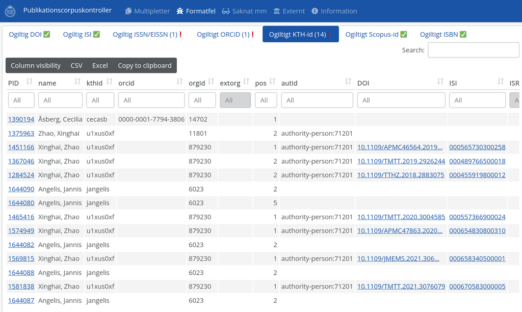

## Data curation tools and data used

Data extracts can be copy/pasted from reports. There are other options, too:

- Downloads from *object storage (S3)*
- [Curator API](https://bibliometrics.lib.kth.se/curator/__docs__/) (authenticated)
- [Checks API](https://bibliometrics.lib.kth.se/qc/__docs__/) (partly authenticated)

[figure not shown]

Curator API

## Demo of KTH Publication Analysis app

## KTH Publication Analysis app

The goal of this app is to help answering some common questions, for example

- What does KTH collaboration with country X or university Y look like?
  - What is the bibliometric impact of this collaboration?
- What is the collaboration pattern and bibliometric impact of…
  - a KTH department, based on Diva affiliations?
  - staff currently or recently employed by some department or division?
  - some group at KTH not clearly defined in Diva or staff catalogue?
  - all the Postdocs at school Z?

## KTH Publication Analysis app

[figure not shown]

## Questions and feedback

## Questions and Answers

Please provide your input!

- Do you think the what was presented in the demonstration meets your needs for more analytical exploration for **collaboration and co-publication** at KTH?
- **Other questions** from the Zoom chat
- Suggestions and **comments**

If you prefer to provide written feedback, please use the following [jamboard](https://jamboard.google.com/d/1qJ9v6JyamDLPS82_qYg9l7scWkJcX8xVY0m6weazJCI/viewer)

Thank you for attending!